# Cyclistic Bike Share Case Study

Zachary Crossey

8/30/2021

# Business Task

The task is to figure out how casual riders and members use the Cyclistic bike-share services, and see if there are any differences that can be discerned from the data.

## Load Libraries

- tidyverse: analytical packages
- lubridate: manipulating date-time data
- ggplot2: visualizations
- dplyr: manipulating data
- mapdata and maps: provides map functionalities

```r
library(tidyverse)
library(lubridate)
```

```r
library(ggplot2)
library(dplyr)
library(mapdata)
library(maps)
```

## Set Work Directory

```r
getwd()
setwd("/Users/zmcro/OneDrive/Documents/Cyclistic Portfolio Project 2/Orig")
```

# Load Datasets

The data consist of the past 12 months from the Cyclistic bike-share program (https://divvy-tripdata.s3.amazonaws.com/index.html). Each month consists of 13 columns, and various number of rows due to rideship varying from each month.

### Below is a brief explanation of the columns:

- ride_id: id for each ride
- rideable_type: type of bike the riders can choose from
- started_at: when the ride started at
- ended_at: when the ride ended at
- start_station_name: where the ride started from
- start_station_id: id of the start station
- end_station_name: where the ride ended at
- end_station_id: id of the end station
- start_lat: latitude of the start station
- start_lng: longitude of the start station
- end_lat: latitude of the end station
- end_lng: longitude of the start station
- member_casual: rider is either a member or a casual rider

```r
Aug_2020 <- read_csv("202008-divvy-tripdata.csv",show_col_types = FALSE)
Sep_2020 <- read_csv("202009-divvy-tripdata.csv",show_col_types = FALSE)
Oct_2020 <- read_csv("202010-divvy-tripdata.csv",show_col_types = FALSE)
Nov_2020 <- read_csv("202011-divvy-tripdata.csv",show_col_types = FALSE)
Dec_2020 <- read_csv("202012-divvy-tripdata.csv",show_col_types = FALSE)
Jan_2021 <- read_csv("202101-divvy-tripdata.csv",show_col_types = FALSE)
Feb_2021 <- read_csv("202102-divvy-tripdata.csv",show_col_types = FALSE)
Mar_2021 <- read_csv("202103-divvy-tripdata.csv",show_col_types = FALSE)
Apr_2021 <- read_csv("202104-divvy-tripdata.csv",show_col_types = FALSE)
May_2021 <- read_csv("202105-divvy-tripdata.csv",show_col_types = FALSE)
Jun_2021 <- read_csv("202106-divvy-tripdata.csv",show_col_types = FALSE)
Jul_2021 <- read_csv("202107-divvy-tripdata.csv",show_col_types = FALSE)
```

## Check consistency of col_names

In order to bind all the datasets into one dataframe, the column names need to be consistent across the board. Using colnames on each months dataframe provides a brief look into whether or not that is the case.

```r
colnames(Aug_2020)
colnames(Sep_2020)
colnames(Oct_2020)
colnames(Nov_2020)
colnames(Dec_2020)
colnames(Jan_2021)
colnames(Feb_2021)
colnames(Mar_2021)
colnames(Apr_2021)
colnames(May_2021)
colnames(Jun_2021)
colnames(Jul_2021)
```

## Checking structure of data

Similar to checking the column names are consistent, it is important that each column across all months dataframes are consistent, as well. In some dataframes, the start_station_id and end_station_id did not match, and were numeric values. To be consistent, I changed each column to be character types to fit with the other dataframes.

```r
str(Aug_2020)
str(Sep_2020)
str(Oct_2020)
str(Nov_2020)
str(Dec_2020)
str(Jan_2021)
str(Feb_2021)
str(Mar_2021)
str(Apr_2021)
str(May_2021)
str(Jun_2021)
str(Jul_2021)

Aug_2020$start_station_id <- as.character(Aug_2020$start_station_id)
Aug_2020$end_station_id <- as.character(Aug_2020$end_station_id)
Sep_2020$start_station_id <- as.character(Sep_2020$start_station_id)
Sep_2020$end_station_id <- as.character(Sep_2020$end_station_id)
Oct_2020$start_station_id <- as.character(Oct_2020$start_station_id)
Oct_2020$end_station_id <- as.character(Oct_2020$end_station_id)
Nov_2020$start_station_id <- as.character(Nov_2020$start_station_id)
Nov_2020$end_station_id <- as.character(Nov_2020$end_station_id)
```

## Combine data into single dataframe

```r
all_trips <- bind_rows(Aug_2020, Sep_2020, Oct_2020, Nov_2020, Dec_2020,
                       Jan_2021, Feb_2021, Mar_2021, Apr_2021, May_2021,
                       Jun_2021, Jul_2021)
```

# Clean and add data for analysis

## Add columns to list day, month, and year of each ride

- The “date” column is taking solely the date data from the date-time.
- The “month”, “day”, and “year” columns are pulling their respective data from the date column.
- The “weekday” column is converting the date into the respective weekday
- The “hhmmss”, “hhmm” and “hh” columns take the hour, minute, and seconds data from the started_at column

```r
all_trips$date <- as.Date(all_trips$started_at)
all_trips$month <- format(all_trips$date, "%m")
all_trips$day <- format(all_trips$date, "%d")
all_trips$year <- format(all_trips$date, "%Y")
all_trips$weekday <- format(all_trips$date, "%A")
all_trips$hhmmss <- format(all_trips$started_at, format="%H:%M:%s")
all_trips$hhmm <- format(all_trips$started_at, format="%H:%M")
all_trips$hh <- format(all_trips$started_at, format="%H")
all_trips$endhh <- format(all_trips$ended_at, format="%H")
```

## Compute the ride_length using start/end times

The ride_length column is created to look at how long each ride was using the ended_at and started_at data.

```r
all_trips$ride_length <- difftime(all_trips$ended_at, all_trips$started_at)
is.factor(all_trips$ride_length)
```

```
## [1] FALSE
```

```r
all_trips$ride_length <- as.numeric(as.character(all_trips$ride_length))
is.numeric(all_trips$ride_length)
```

```
## [1] TRUE
```

## Compute the distance using haversine formula with the lat/long for start/end

Although it is a stretch to look at the distance of each ride given the lack of tracking data from each bike ride, I thought it would be interesting to look at how potentially far each ride went. Using the haversine formula, I took the start lat/lng and end lat/lng data to determine how far each ride went.

```r
my_dist <- function(long1, lat1, long2, lat2) {
  rad <- pi/180
  a1 <- lat1*rad
  a2 <- long1*rad
  b1 <- lat2*rad
  b2 <- long2*rad
  dlon <- b2 - a2
  dlat <- b1 - a1
  a <- (sin(dlat/2))^2 + cos(a1)*cos(b1)*(sin(dlon/2))^2
  c <- 2*atan2(sqrt(a), sqrt(1 - a))
  R <- 6378137
  d <- R*c
  m <- round(d/1600, digits = 2)
  return(m)
}

# Creating column for haversine computation
all_trips$distHav <- my_dist(all_trips$start_lng, all_trips$start_lat,
                             all_trips$end_lng, all_trips$end_lat)
```

## Filter and sort data

To filter out all the data that would hurt the analysis, I filtered the data to not include start_station_names with the value of “WATSON TESTING - DIVVY”, and ride_length and distHav that were less than 0, since we do not want negative values.

```r
# Filter out data that ruins analysis and sort by yyyy-mm-dd and hh:mm:ss
all_trips_sorted <- filter(all_trips, !(start_station_name=="WATSON TESTING - DIVVY" | ride_length<0 | distHav<0)) %>%
  arrange(year, month, day, hhmmss)
```

# Descriptive analysis

The ultimate goal of this case study is “How do annual members and casual riders use Cyclistic bikes differently?”  
Below I ask several questions to see how different members and casual riders are through August 2020-July 2021, and have provided visuals in certain instances to highlight key information.

## QUESTION: Examining difference in number of rides per month

To begin, I wanted to look at the number of rides per month by members and casual riders, and the average duration of each ride. The first piece of code gives a summary view of the number of rides and average duration by members and casual riders per month. The second piece of code shows a visual of that summary.

```r
# number of rides per month
all_trips_sorted %>%
  mutate(month = lubridate::month(started_at, label=TRUE)) %>%
  group_by(member_casual, month) %>%
  summarise(number_of_rides = n(), avg_duration=mean(ride_length)) %>%
  arrange(member_casual)
```

```
## # A tibble: 24 x 4
## # Groups:   member_casual [2]
##    member_casual month number_of_rides avg_duration
##    <chr>         <ord>           <int>        <dbl>
##  1 casual        Jan             15894        1545.
##  2 casual        Feb              9161        2836.
##  3 casual        Mar             78757        2280.
##  4 casual        Apr            125994        2278.
##  5 casual        May            230839        2333.
##  6 casual        Jun            327306        2261.
##  7 casual        Jul            393881        1967.
##  8 casual        Aug            283347        2667.
##  9 casual        Sep            220406        2300.
## 10 casual        Oct            130402        1861.
## # ... with 14 more rows
```

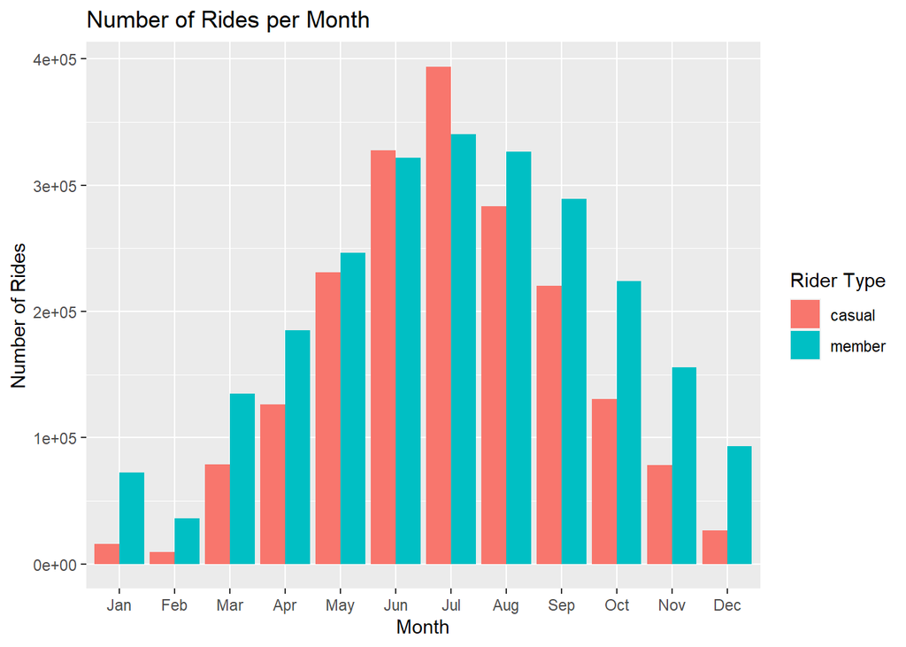

```r
# number of rides per month (graph)
all_trips_sorted %>%
  mutate(month = lubridate::month(started_at, label=TRUE)) %>%
  group_by(member_casual, month) %>%
  summarise(number_of_rides = n(), avg_duration=mean(ride_length)) %>%
  ggplot(aes(x=month, y=number_of_rides, fill=member_casual)) +
  geom_col(position="dodge")+
  labs(title="Number of Rides per Month") + xlab("Month") + ylab("Number of Rides") +
  guides(fill=guide_legend(title="Rider Type"))
```

#### Analysis: * Casual ridership dips well below 100,000 rides from November through February * Casual ridership steadily increases from March throughout the summer, hitting its peak in July * Member ridership fell in the same time period, but remained much higher compared * Member ridership is higher compared to casual ridership most months (excluding June and July) * overall, members have a higher number of rides throughout the year, but casual ridership is higher during the summer months

## QUESTION: Looking at difference in number of rides per month by day

The next question to look into was whether there was a difference in the number of rides by day in each month. The pieces of code provide a visual of the percentage of rides by day in each month.

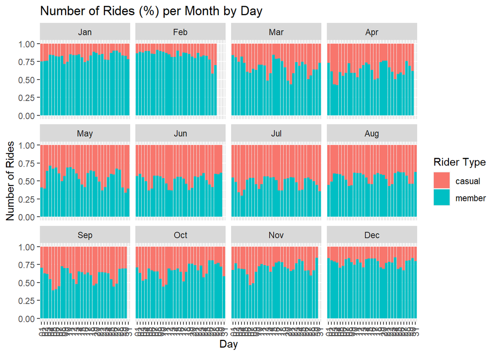

```r
# number of rides per month by day (graph)
num_rides_dow <-all_trips_sorted %>%
  mutate(month = lubridate::month(started_at, label=TRUE)) %>%
  group_by(member_casual, month, day) %>%
  summarise(number_of_rides = n(), avg_duration=mean(ride_length)) %>%
  ggplot(aes(x=day, y=number_of_rides, fill=member_casual, shape = member_casual)) +
  geom_col(position="fill") +
  facet_wrap(~month) +
  theme(axis.text.x = element_text(angle = 90, vjust = 0.5, hjust=1))
num_rides_dow +
  labs(title="Number of Rides (%) per Month by Day") + xlab("Day") + ylab("Number of Rides") +
  guides(fill=guide_legend(title="Rider Type"))
```

#### Analysis:

- Member ridership is higher the majority of days throughout each month
- Casual ridership follows a pattern of being higher every 7 days starting from late May to mid October
- More information would be needed to determine if there is a weekday that experiences higher ridership between the two types of riders

## QUESTION: Looking at ride length between members and casuals

Besides the number of rides, it was also important to look at the length of each ride between members and casual riders. The pieces of code go through some basic statistics of ride length between the members and casual members.

```r
# Looking at ride_length between members and casuals
aggregate(all_trips_sorted$ride_length ~ all_trips_sorted$member_casual, FUN=mean)
```

```
##   all_trips_sorted$member_casual all_trips_sorted$ride_length
## 1                         casual                    2224.8778
## 2                         member                     871.1598
```

```r
aggregate(all_trips_sorted$ride_length ~ all_trips_sorted$member_casual, FUN=median)
```

```
##   all_trips_sorted$member_casual all_trips_sorted$ride_length
## 1                         casual                         1109
## 2                         member                          634
```

```r
aggregate(all_trips_sorted$ride_length ~ all_trips_sorted$member_casual, FUN=max)
```

```
##   all_trips_sorted$member_casual all_trips_sorted$ride_length
## 1                         casual                      3356649
## 2                         member                      2005282
```

#### Analysis:

- Casual ridership has a higher average ride length compared to member ridership (2224.88 seconds to 871.16 seconds)
- Casual ridership also has a higher median ride length compared to member ridership (1109 seconds to 634 seconds)

## QUESTION: Looking at distance traveled between members and casuals

The distance of each ride was looked at, as well. Although it should be noted that round trips would equate to a distance of zero. This was to see if there was any valuable information to see if casual riders and members ride different distances.

```r
# Looking at distance traveled between members and casuals
aggregate(all_trips_sorted$distHav ~ all_trips_sorted$member_casual, FUN=mean)
```

```
##   all_trips_sorted$member_casual all_trips_sorted$distHav
## 1                         casual                 1.387441
## 2                         member                 1.385164
```

```r
aggregate(all_trips_sorted$distHav ~ all_trips_sorted$member_casual, FUN=median)
```

```
##   all_trips_sorted$member_casual all_trips_sorted$distHav
## 1                         casual                     1.07
## 2                         member                     1.04
```

```r
aggregate(all_trips_sorted$distHav ~ all_trips_sorted$member_casual, FUN=max)
```

```
##   all_trips_sorted$member_casual all_trips_sorted$distHav
## 1                         casual                    21.15
## 2                         member                    30.27
```

#### Analysis:

- Casual and member ridership have similar average and median distance values, so no real difference to discern
- Member ridership, however, has a higher max distance (30.27 miles to 21.15 miles)

## QUESTION: Seeing if there is a popular start/end station between members and casuals

Columns of interest also included the start/end stations and with their geo data (lat/lng). Thus, it would be good to view where casual riders and members start/end their ride. The first couple pieces of code look at the most popular start/end stations by casual riders and members, while the third piece of code filters out the end stations that are not specified. The following pieces of code focus in on geo locations of the start stations, along with the non-specified end stations. There was more of a focus on non-specified end stations to possibly see if there are potential new stations to put in based on how numerous a given location appears.

```r
# Looking into what is the most popular start stations between members and casuals
popular_start <- all_trips_sorted %>%
  group_by(member_casual,start_station_name) %>%
  count() %>%
  arrange(desc(n))
popular_start
```

```
## # A tibble: 1,453 x 3
## # Groups:   member_casual, start_station_name [1,453]
##    member_casual start_station_name             n
##    <chr>         <chr>                      <int>
##  1 casual        Streeter Dr & Grand Ave    52218
##  2 casual        Lake Shore Dr & Monroe St  31638
##  3 casual        Millennium Park            29991
##  4 casual        Michigan Ave & Oak St      25681
##  5 member        Clark St & Elm St          24327
##  6 casual        Theater on the Lake        22323
##  7 casual        Lake Shore Dr & North Blvd 22173
##  8 member        Wells St & Concord Ln      20547
##  9 member        Kingsbury St & Kinzie St   19869
## 10 casual        Shedd Aquarium             19390
## # ... with 1,443 more rows
```

```r
# Looking into what is the most popular end stations between members and casuals
popular_end <- all_trips_sorted %>%
  filter(!is.na(end_station_name)) %>%
  group_by(member_casual, end_station_name) %>%
  count() %>%
  arrange(desc(n))
popular_end
```

```
## # A tibble: 1,439 x 3
## # Groups:   member_casual, end_station_name [1,439]
##    member_casual end_station_name               n
##    <chr>         <chr>                      <int>
##  1 casual        Streeter Dr & Grand Ave    54693
##  2 casual        Millennium Park            30724
##  3 casual        Lake Shore Dr & Monroe St  29774
##  4 casual        Michigan Ave & Oak St      26332
##  5 casual        Lake Shore Dr & North Blvd 25121
##  6 casual        Theater on the Lake        24287
##  7 member        Clark St & Elm St          24125
##  8 member        Wells St & Concord Ln      20558
##  9 member        Kingsbury St & Kinzie St   19725
## 10 member        Dearborn St & Erie St      18204
## # ... with 1,429 more rows
```

```r
# Looking into the non-specified end stations
all_trips_sorted %>%
  filter(is.na(end_station_name)) %>%
  group_by(member_casual, end_station_name) %>%
  count() %>%
  arrange(desc(n))
```

```
## # A tibble: 2 x 3
## # Groups:   member_casual, end_station_name [2]
##   member_casual end_station_name     n
##   <chr>         <chr>            <int>
## 1 casual        <NA>             96921
## 2 member        <NA>             91303
```

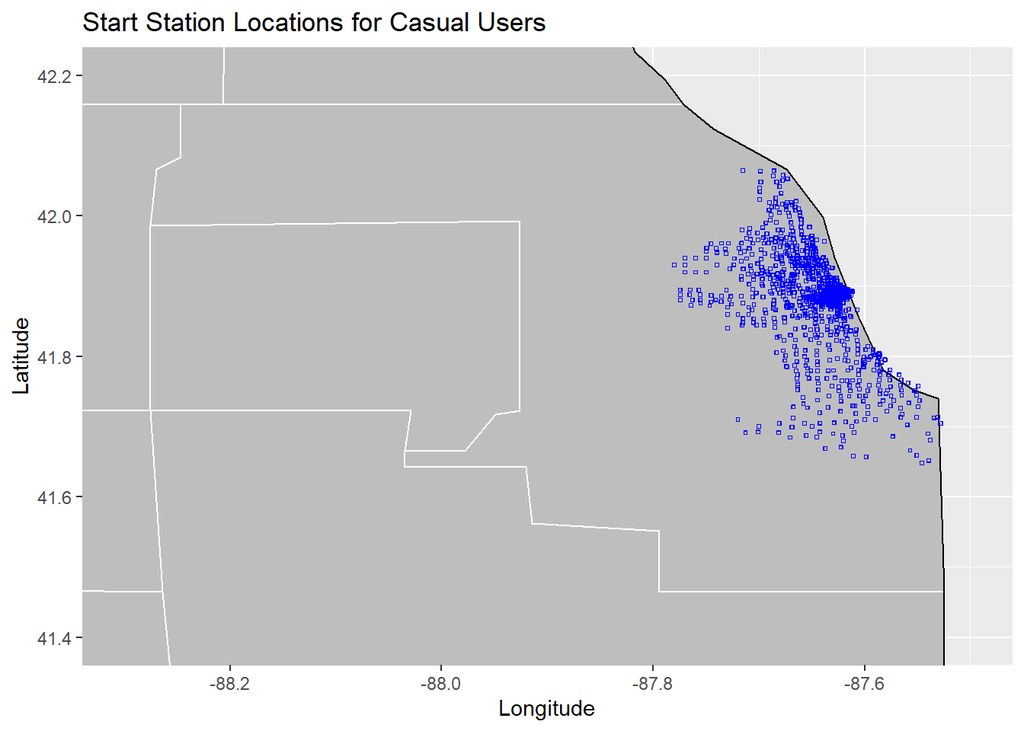

```r
# Looking at map of Cook County start stations
usa <- map_data("usa")
states <- map_data("state")
chicago <- subset(states, region=="illinois")

chicago_plot <- ggplot(chicago, aes(long,lat, group=group)) +
  coord_fixed(1)+ geom_polygon(color='black', fill='gray')
counties <- map_data("county")

illi_counties <- subset(counties, region=='illinois')

# Start stations used by casuals
start_stat_casuals <- all_trips_sorted %>%
  filter(member_casual=="casual"&ride_length>60) %>%
  select(c(ride_id,rideable_type,start_station_name,start_lng, start_lat,member_casual,
           date,month,day,year,weekday,ride_length,distHav))

starts_casuals <- chicago_plot + geom_polygon(data=illi_counties, fill=NA,color="white") +
  geom_polygon(fill=NA,color="black") + coord_cartesian(xlim = c(xlim=-88.3,-87.5),ylim=c(41.4,42.2)) +
  geom_point(data=start_stat_casuals, aes(start_lng,start_lat),pch=0, size=0.5, color = 'blue', inherit.aes = FALSE)
starts_casuals +
  labs(title="Start Station Locations for Casual Users") + xlab("Longitude") + ylab("Latitude")
```

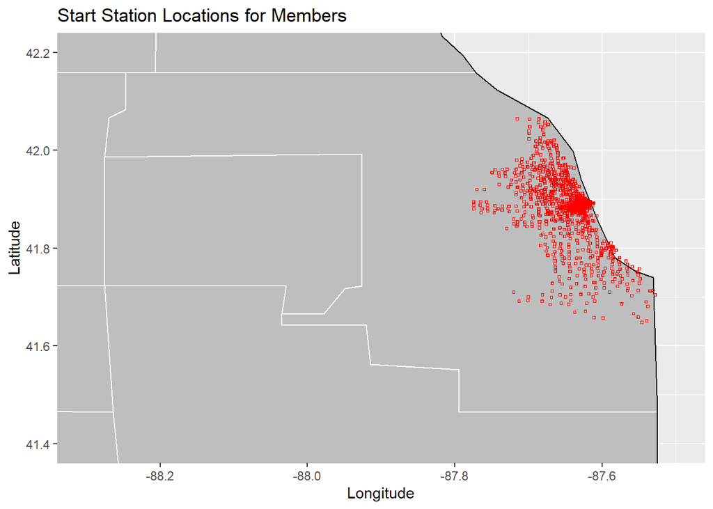

```r
# start stations used by members
start_stat_members <- all_trips_sorted %>%
  filter(member_casual=="member"&ride_length>60) %>%
  select(c(ride_id,rideable_type,start_station_name,start_lng, start_lat,member_casual,
           date,month,day,year,weekday,ride_length,distHav))

starts_members <- chicago_plot + geom_polygon(data=illi_counties, fill=NA,color="white") +
  geom_polygon(fill=NA,color="black") + coord_cartesian(xlim = c(xlim=-88.3,-87.5),ylim=c(41.4,42.2)) +
  geom_point(data=start_stat_members, aes(start_lng,start_lat),pch=0, size=0.5, color = 'red', inherit.aes = FALSE)
starts_members +
  labs(title="Start Station Locations for Members") + xlab("Longitude") + ylab("Latitude")
```

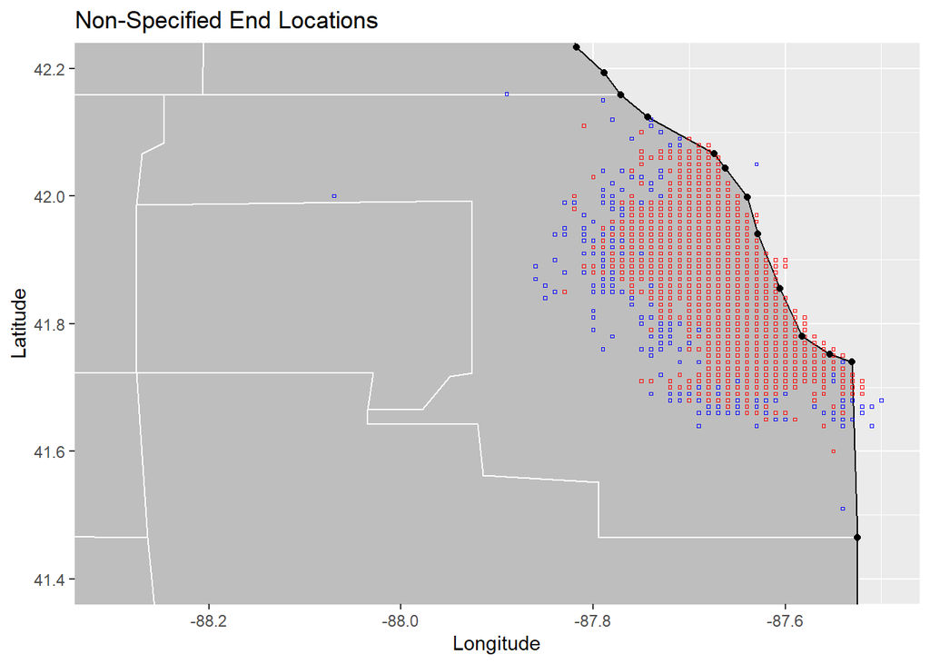

```r
# bikes left at non-specified end stations for casuals
casual_no_station <- all_trips_sorted %>%
  filter(member_casual=="casual"&ride_length>60&is.na(end_station_name)) %>%
  group_by(end_lng, end_lat) %>%
  select(c(ride_id,rideable_type,end_station_name,end_lng, end_lat,member_casual,
           date,month,day,year,weekday,ride_length,distHav))

# bikes left at non-specified end stations for members
member_no_station <- all_trips_sorted %>%
  filter(member_casual=="member"&ride_length>60&is.na(end_station_name)) %>%
  group_by(end_lng, end_lat) %>%
  select(c(ride_id,rideable_type,end_station_name,end_lng, end_lat,member_casual,
           date,month,day,year,weekday,ride_length,distHav))

# bikes left at non-specified end stations for all riders
no_station <- chicago_plot + geom_polygon(data=illi_counties, fill=NA,color="white") +
  geom_polygon(fill=NA,color="black") + coord_cartesian(xlim = c(xlim=-88.3,-87.5),ylim=c(41.4,42.2)) +
  geom_point(data=casual_no_station, aes(end_lng,end_lat),pch=0,size=0.5,color="blue", inherit.aes = FALSE) +
  geom_point(data=member_no_station, aes(end_lng,end_lat),pch=0,size=0.5,color="red", inherit.aes = FALSE) +
  layer(geom = "point", stat="identity", position="identity")
no_station +
  labs(title="Non-Specified End Locations") + xlab("Longitude") + ylab("Latitude") +
  guides(fill=guide_legend(title="Rider Type"))
```

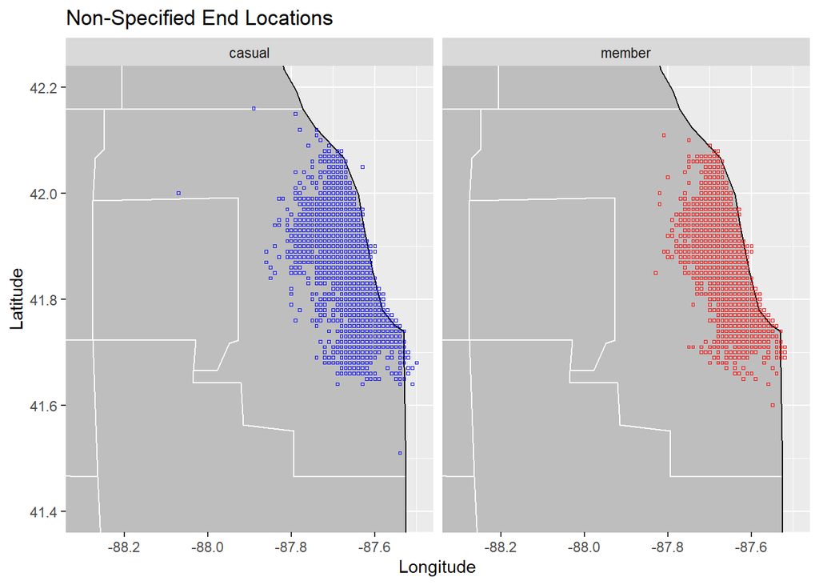

```r
no_station_facet <- chicago_plot + geom_polygon(data=illi_counties, fill=NA,color="white") +
  geom_polygon(fill=NA,color="black") + coord_cartesian(xlim = c(xlim=-88.3,-87.5),ylim=c(41.4,42.2)) +
  geom_point(data=casual_no_station, aes(end_lng,end_lat),pch=0,size=0.5, color='blue', inherit.aes = FALSE) +
  geom_point(data=member_no_station, aes(end_lng,end_lat),pch=0,size=0.5, color='red', inherit.aes = FALSE) +
  facet_wrap(~member_casual)
no_station_facet +
  labs(title="Non-Specified End Locations") + xlab("Longitude") + ylab("Latitude") +
  guides(fill=guide_legend(title="Rider Type"))
```

#### Analysis:

- The most popular start station for casuals rider is “Streeter Dr & Grand Ave” with 52,218 instances
- The most popular start station for members is “Clark St & Elm St” with 24,327 instances
- The maps show that casual riders and members generally use the same start stations with differing usage rates
- The maps also show the same thing with non-specified end stations, but casual riders are more spread out with where they place their bikes.

## QUESTION: Looking at the ride_length per members and casuals on a given day

The next question to look into was whether there was a difference in how long each ride lasted on a given weekday between casual riders and members. The first few pieces of code provides a summary by rider type and weekday of each average ride length. The next piece of code provides a visualization of that summary.

```r
aggregate(all_trips_sorted$ride_length ~ all_trips_sorted$member_casual+all_trips_sorted$weekday, FUN=mean)
```

```
##    all_trips_sorted$member_casual all_trips_sorted$weekday
## 1                          casual                   Friday
## 2                          member                   Friday
## 3                          casual                   Monday
## 4                          member                   Monday
## 5                          casual                 Saturday
## 6                          member                 Saturday
## 7                          casual                   Sunday
## 8                          member                   Sunday
## 9                          casual                 Thursday
## 10                         member                 Thursday
## 11                         casual                  Tuesday
## 12                         member                  Tuesday
## 13                         casual                Wednesday
## 14                         member                Wednesday
##    all_trips_sorted$ride_length
## 1                     2113.8031
## 2                      852.7202
## 3                     2185.8858
## 4                      841.0669
## 5                     2388.8009
## 6                      961.9687
## 7                     2568.1400
## 8                      995.6086
## 9                     1941.9123
## 10                     811.9179
## 11                    1976.7517
## 12                     821.4285
## 13                    1976.9892
## 14                     826.4828
```

```r
all_trips_sorted$weekday <- ordered(all_trips_sorted$weekday, levels=c("Sunday", "Monday", "Tuesday",
                                                                       "Wednesday", "Thursday", "Friday",
                                                                       "Saturday"))
aggregate(all_trips_sorted$ride_length ~ all_trips_sorted$member_casual+all_trips_sorted$weekday, FUN=mean)
```

```
##    all_trips_sorted$member_casual all_trips_sorted$weekday
## 1                          casual                   Sunday
## 2                          member                   Sunday
## 3                          casual                   Monday
## 4                          member                   Monday
## 5                          casual                  Tuesday
## 6                          member                  Tuesday
## 7                          casual                Wednesday
## 8                          member                Wednesday
## 9                          casual                 Thursday
## 10                         member                 Thursday
## 11                         casual                   Friday
## 12                         member                   Friday
## 13                         casual                 Saturday
## 14                         member                 Saturday
##    all_trips_sorted$ride_length
## 1                     2568.1400
## 2                      995.6086
## 3                     2185.8858
## 4                      841.0669
## 5                     1976.7517
## 6                      821.4285
## 7                     1976.9892
## 8                      826.4828
## 9                     1941.9123
## 10                     811.9179
## 11                    2113.8031
## 12                     852.7202
## 13                    2388.8009
## 14                     961.9687
```

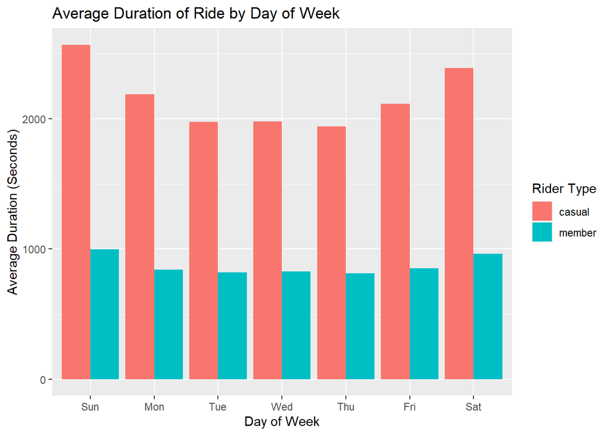

```r
# avg duration vs dow
avg_dur_dow <- all_trips_sorted %>%
  mutate(dow = wday(started_at, label=TRUE)) %>%
  group_by(member_casual, dow) %>%
  summarise(number_of_rides = n(), avg_duration=mean(ride_length)) %>%
  arrange(member_casual, dow) %>%
  ggplot(aes(x=dow, y=avg_duration, fill=member_casual)) + geom_col(position="dodge")
avg_dur_dow +
  labs(title="Average Duration of Ride by Day of Week") + xlab("Day of Week") + ylab("Average Duration (Seconds)") +
  guides(fill=guide_legend(title="Rider Type"))
```

#### Analysis:

- Casual ridership has a higher average ride length across all weekdays, and in each day more than doubling the member ridership average ride length

## QUESTION: Looking at the number of rides per members and casuals on a given day

Going off ride length by weekday, the next thing to look into was the number of rides by weekday between casual riders and members. The first piece of provides another summary of the number of rides and average ride length by weekday between casual riders and members. The second piece of code provides a visualization of the number of rides by weekday.

```r
# dow: number of rides with avg duration
all_trips_sorted %>%
  mutate(dow = wday(started_at, label=TRUE)) %>%
  group_by(member_casual, dow) %>%
  summarise(number_of_rides = n(), avg_duration=mean(ride_length)) %>%
  arrange(member_casual, dow)
```

```
## # A tibble: 14 x 4
## # Groups:   member_casual [2]
##    member_casual dow   number_of_rides avg_duration
##    <chr>         <ord>           <int>        <dbl>
##  1 casual        Sun            364749        2568.
##  2 casual        Mon            208840        2186.
##  3 casual        Tue            201290        1977.
##  4 casual        Wed            208948        1977.
##  5 casual        Thu            208935        1942.
##  6 casual        Fri            274676        2114.
##  7 casual        Sat            453326        2389.
##  8 member        Sun            304879         996.
##  9 member        Mon            322868         841.
## 10 member        Tue            351869         821.
## 11 member        Wed            370056         826.
## 12 member        Thu            351358         812.
## 13 member        Fri            358046         853.
## 14 member        Sat            365862         962.
```

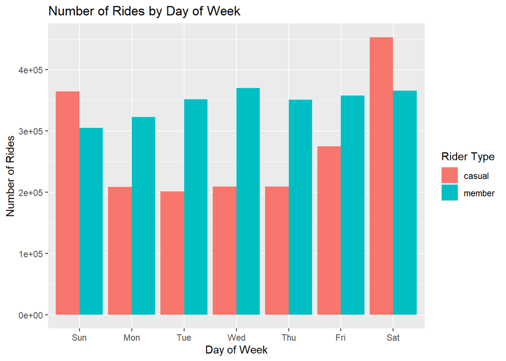

```r
# number of rides vs dow
num_rides_dow <- all_trips_sorted %>%
  mutate(dow = wday(started_at, label=TRUE)) %>%
  group_by(member_casual, dow) %>%
  summarise(number_of_rides = n(), avg_duration=mean(ride_length)) %>%
  arrange(member_casual, dow) %>%
  ggplot(aes(x=dow, y=number_of_rides, fill=member_casual)) + geom_col(position="dodge")
num_rides_dow +
  labs(title="Number of Rides by Day of Week") + xlab("Day of Week") + ylab("Number of Rides") +
  guides(fill=guide_legend(title="Rider Type"))
```

#### Analysis::

- Casual ridership in terms of number of rides is highest during the weekend, which may indicate that the casual riders do more leisurely riding
- Member ridership has a higher number of rides throughout the week however

## QUESTION: Looking at the ride_length per members and casuals in a given month

Furthering the discussion of ride length, the last thing to look into was the average ride length per month between casual riders and members. The first piece of code provides a look into each month the average ride length of each rider type. The second piece of code provides a visualization of the data.

```r
aggregate(all_trips_sorted$ride_length ~ all_trips_sorted$member_casual+all_trips_sorted$month, FUN=mean)
```

```
##    all_trips_sorted$member_casual all_trips_sorted$month
## 1                          casual                     01
## 2                          member                     01
## 3                          casual                     02
## 4                          member                     02
## 5                          casual                     03
## 6                          member                     03
## 7                          casual                     04
## 8                          member                     04
## 9                          casual                     05
## 10                         member                     05
## 11                         casual                     06
## 12                         member                     06
## 13                         casual                     07
## 14                         member                     07
```

[output cut: 35 more lines]

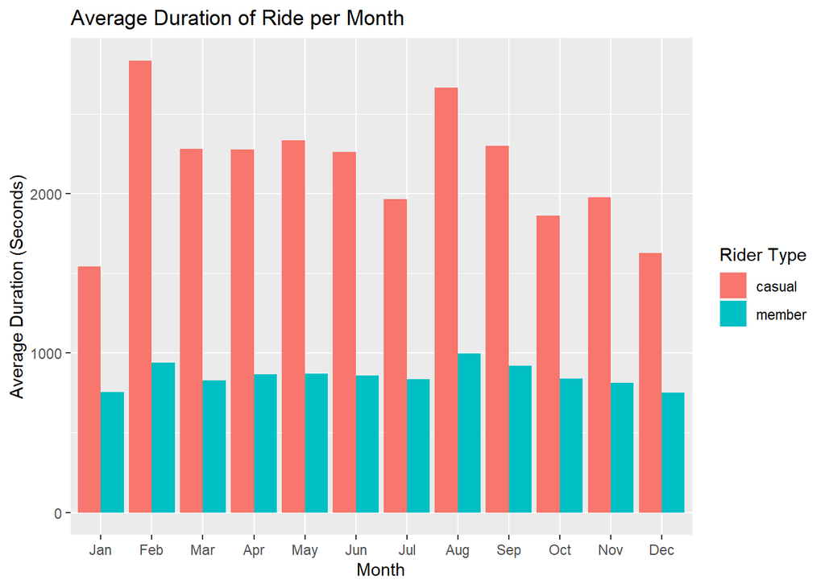

```r
# avg duration per month
avg_dur_month <- all_trips_sorted %>%
  mutate(month = lubridate::month(started_at, label=TRUE)) %>%
  group_by(member_casual, month) %>%
  summarise(number_of_rides = n(), avg_duration=mean(ride_length)) %>%
  arrange(member_casual, month) %>%
  ggplot(aes(x=month, y=avg_duration, fill=member_casual)) + geom_col(position="dodge")
avg_dur_month +
  labs(title="Average Duration of Ride per Month") + xlab("Month") + ylab("Average Duration (Seconds)") +
  guides(fill=guide_legend(title="Rider Type"))
```

#### Analysis:

- Casual ridership has the highest average ride length across the entire year
- Member ridership only reached 1000 seconds once, and is close to half or more so than the casual ridership average ride length
- The difference in usage could indicate how each rider type uses the service

## QUESTION: Looking at if there is a difference in the type of bike used by members and casuals

Another thing to look into is if there is a type of bike that casual riders and members prefer to use. The first piece of code looks at the bike type usage between casual riders and members, and the second piece of code looks into the bike type usage by month between casual riders and members. The last pieces of codes provide visuals for that data.

```r
popular_bike_type <- all_trips_sorted %>%
  group_by(member_casual,rideable_type) %>%
  count() %>%
  arrange(member_casual, desc(n))
popular_bike_type
```

```
## # A tibble: 6 x 3
## # Groups:   member_casual, rideable_type [6]
##   member_casual rideable_type       n
##   <chr>         <chr>           <int>
## 1 casual        docked_bike    756872
## 2 casual        classic_bike   693395
## 3 casual        electric_bike  470497
## 4 member        classic_bike  1089370
## 5 member        docked_bike    791077
## 6 member        electric_bike  544491
```

```r
popular_bike_month <- all_trips_sorted %>%
  group_by(rideable_type, member_casual,month) %>%
  count() %>%
  arrange(member_casual, desc(n))
popular_bike_month
```

```
## # A tibble: 58 x 4
## # Groups:   rideable_type, member_casual, month [58]
##    rideable_type member_casual month      n
##    <chr>         <chr>         <chr>  <int>
##  1 docked_bike   casual        08    259621
##  2 classic_bike  casual        07    240899
##  3 classic_bike  casual        06    187717
##  4 docked_bike   casual        09    170834
##  5 classic_bike  casual        05    123611
##  6 electric_bike casual        07     95284
##  7 electric_bike casual        06     87873
##  8 docked_bike   casual        10     79226
##  9 classic_bike  casual        04     70589
## 10 electric_bike casual        05     63875
## # ... with 48 more rows
```

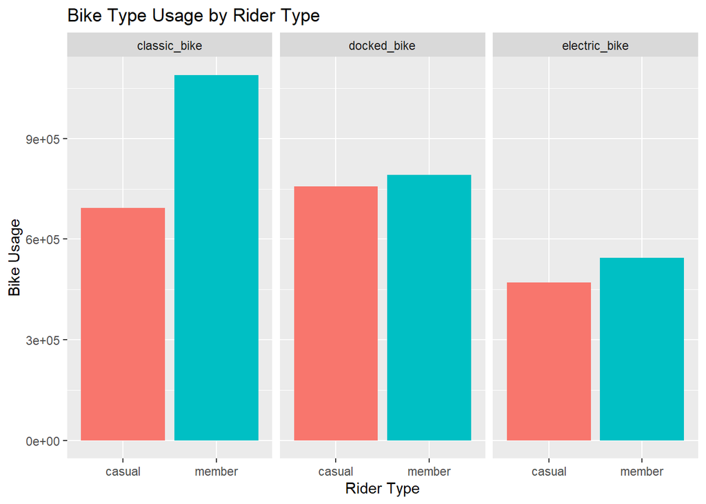

```r
# by type of bike
bike_type_riders <- all_trips_sorted %>%
  group_by(rideable_type, member_casual) %>%
  summarise(num_bike = n()) %>%
  arrange(member_casual) %>%
  ggplot(aes(x=member_casual, y=num_bike, fill=member_casual,show.legend = FALSE)) +
  geom_col(position="dodge") +
  facet_wrap(~rideable_type)
bike_type_riders +
  labs(title="Bike Type Usage by Rider Type") + xlab("Rider Type") + ylab("Bike Usage") +
  theme(legend.position = "none")
```

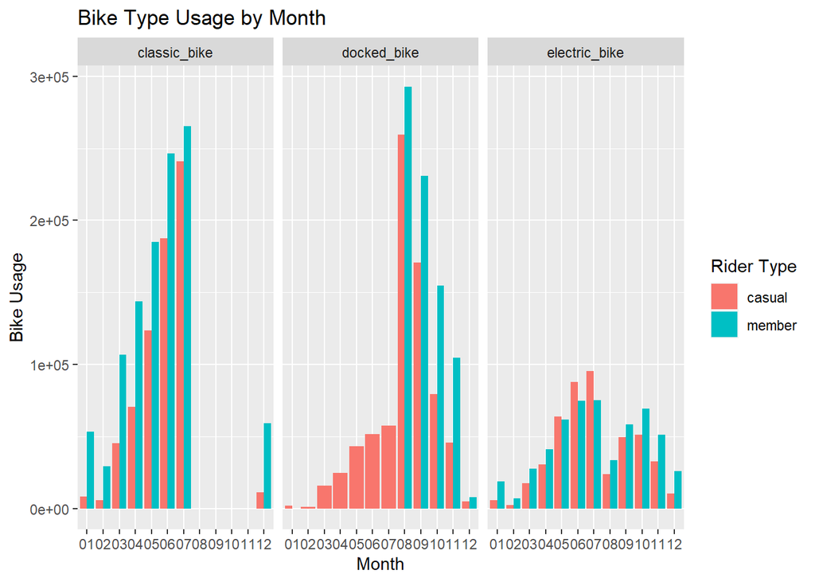

```r
# by type of bike per month
bike_type_month <- all_trips_sorted %>%
  group_by(rideable_type, member_casual,month) %>%
  summarise(num_bike = n()) %>%
  arrange(member_casual) %>%
  ggplot(aes(x=month, y=num_bike, fill=member_casual)) + geom_col(position="dodge") +
  facet_grid(~rideable_type)
bike_type_month +
  labs(title="Bike Type Usage by Month") + xlab("Month") + ylab("Bike Usage") +
  guides(fill=guide_legend(title="Rider Type"))
```

#### Analysis:

- Casual ridership prefers the docked bike, and least prefers the electric bike
- Member ridership preferes the classic bike, and least prefers the electric bike

## QUESTION: Looking at if there is a difference in the time of day for rides between members and casuals

The last thing to look into is to see when rides start between casual riders and members by month. The two pieces of code provide a time-of-day look by month between the rider type.

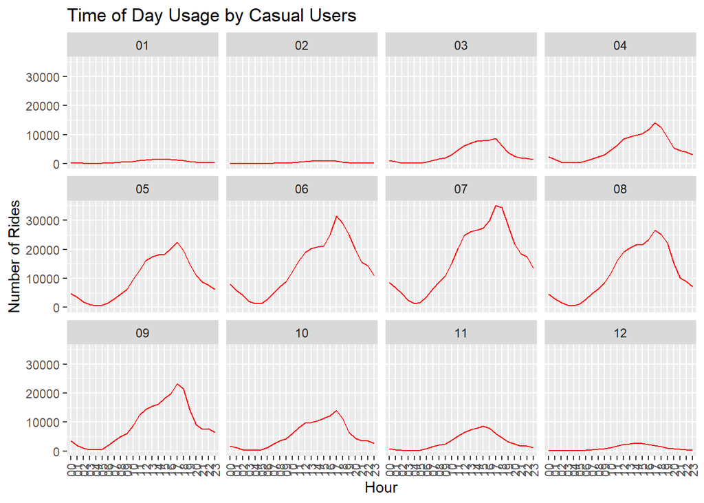

```r
tod_casual <- all_trips_sorted %>%
  filter(member_casual=="casual") %>%
  group_by(member_casual, month, hh) %>%
  summarise(num_rides=n()) %>%
  ggplot(aes(x=hh, y=num_rides,group=1)) + geom_path(color="red") +
  theme(axis.text.x = element_text(angle = 90, vjust = 0.5, hjust=1)) +
  facet_wrap(~month)
tod_casual +
  labs(title="Time of Day Usage by Casual Users") + xlab("Hour") + ylab("Number of Rides")
```

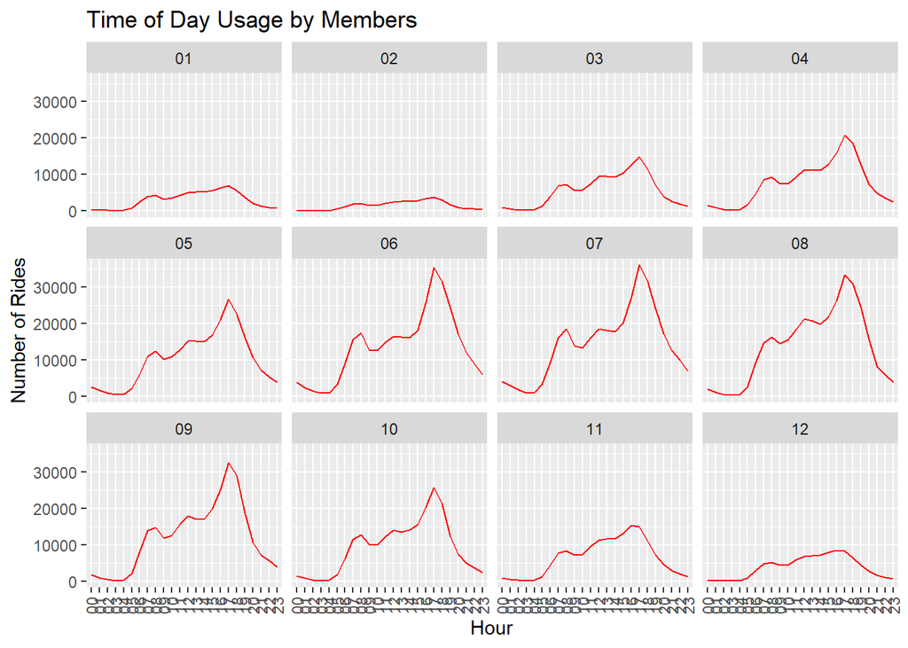

```r
tod_members <- all_trips_sorted %>%
  filter(member_casual=="member") %>%
  group_by(member_casual, month, hh) %>%
  summarise(num_rides=n()) %>%
  ggplot(aes(x=hh, y=num_rides,group=1)) + geom_path(color="red") +
  theme(axis.text.x = element_text(angle = 90, vjust = 0.5, hjust=1)) +
  facet_wrap(~month)
tod_members +
  labs(title="Time of Day Usage by Members") + xlab("Hour") + ylab("Number of Rides")
```

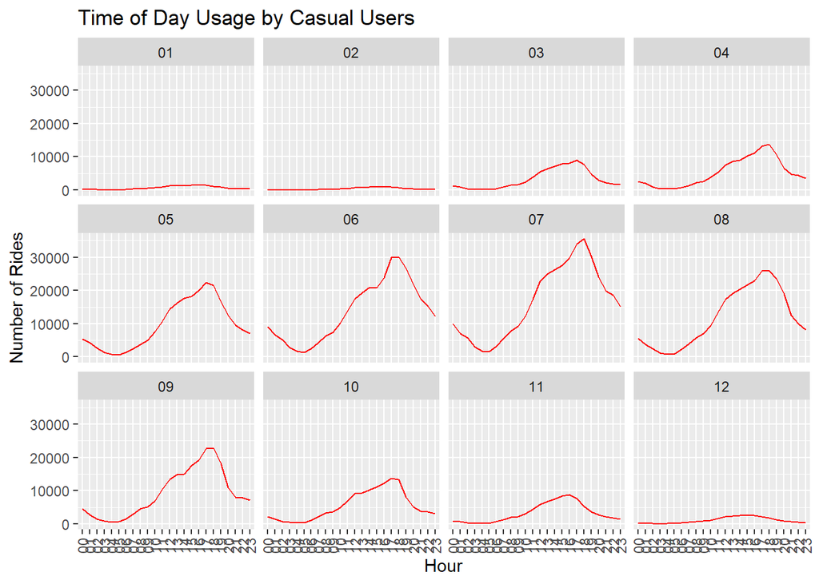

```r
# Looking into when rides usually end between casuals and  members
tod_casual_end <- all_trips_sorted %>%
  filter(member_casual=="casual") %>%
  group_by(member_casual, month, endhh) %>%
  summarise(num_rides=n()) %>%
  ggplot(aes(x=endhh, y=num_rides,group=1)) + geom_path(color="red") +
  theme(axis.text.x = element_text(angle = 90, vjust = 0.5, hjust=1)) +
  facet_wrap(~month)
tod_casual_end +
  labs(title="Time of Day Usage by Casual Users") + xlab("Hour") + ylab("Number of Rides")
```

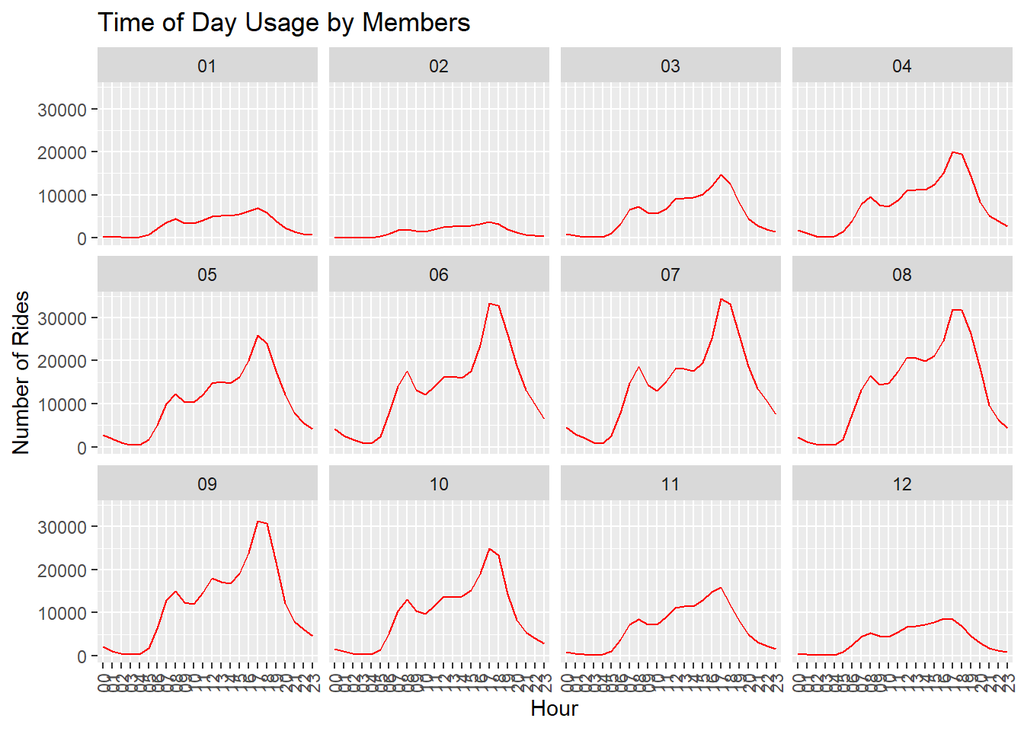

```r
tod_members_end <- all_trips_sorted %>%
  filter(member_casual=="member") %>%
  group_by(member_casual, month, endhh) %>%
  summarise(num_rides=n()) %>%
  ggplot(aes(x=endhh, y=num_rides,group=1)) + geom_path(color="red") +
  theme(axis.text.x = element_text(angle = 90, vjust = 0.5, hjust=1)) +
  facet_wrap(~month)
tod_members_end +
  labs(title="Time of Day Usage by Members") + xlab("Hour") + ylab("Number of Rides")
```

#### Analysis:

- Casual ridership during the winter months show hardly any activity
- However, during late Spring-early Summer period, casual ridership experiences little activity in the morning but rises in the late afternoon
- Member ridership experiences higher activity in the morning and late afternoon, but remains steady between the two periods

# Summary

Overall, casual riders tend to ride for longer periods of time and shows higher number of rides on the weekends. The time data suggests that casual riders use the service for leisure due to the low usage in the morning and at night, which also suggests there are little number of casual riders that use it for getting to work. Also, casual ridership increases during the summer months, suggesting that when the weather warms up, casual ridership increases. Members tend to ride for shorter periods of time and show higher number of rides during the week. The time data suggests that members use it for work, due to the high usage in the morning and late afternoon. Also, member ridership remains high during most of the year, even though the winter months are understandably lower.

# Recommendations

- Casual riders tend to do more of their riding during the summer months (late May-early September)
- Members tend to do most of their riding during the morning through the late afternoon
- Casual riders tend to ride longer than members do